# Problem Set 10

2018-11-28

# Collaboration

Please indicate who you collaborated with on this problem set:

# Background

For this exercise, we will mimic the tactile sampling you did in class with virtual sampling. We will use some data from the [general social survey](http://gss.norc.org/), an annual personal-interview survey conducted in the United States. The survey is designed to monitor changes in both social characteristics and attitudes.

For this exercise, the “study population” will not be the US population, but rather 2538 individuals living in a single neighborhood whose information are saved in the `gss_cat` data frame in the `forcats` package. As an analogy to the tactile sampling you did in class, the neighborhood is the “bowl” and the 2,538 people are the little balls. We will use sampling to estimate a certain *population proportion* $p$ of interest:

> The proportion of the study population who are divorced

Now you might ask yourself, if we have all 2538 individual’s saved in `gss_cat` then why are we sampling to estimate these population proportions $p$? Can’t we just compute both population proportions exactly? You are correct! We are only sampling from `gss_cat` as an exercise to study *sampling variation*. In a real life sampling study with a realistic study population, we won’t have access to everyone’s data!

## Setup

First load the necessary packages:

```r
library(ggplot2)
library(dplyr)
library(forcats)
library(moderndive)
library(readr)
```

Next let’s explore the `gss_cat` data set in the `forcats` package using the `glimpse()` function (note that the `forcats` package was loaded automatically with tidyverse).

```r
glimpse(gss_cat)
```

```
## Observations: 21,483
## Variables: 9
## $ year    <int> 2000, 2000, 2000, 2000, 2000, 2000, 2000, 2000, 2000, ...
## $ marital <fct> Never married, Divorced, Widowed, Never married, Divor...
## $ age     <int> 26, 48, 67, 39, 25, 25, 36, 44, 44, 47, 53, 52, 52, 51...
## $ race    <fct> White, White, White, White, White, White, White, White...
## $ rincome <fct> $8000 to 9999, $8000 to 9999, Not applicable, Not appl...
## $ partyid <fct> Ind,near rep, Not str republican, Independent, Ind,nea...
## $ relig   <fct> Protestant, Protestant, Protestant, Orthodox-christian...
## $ denom   <fct> Southern baptist, Baptist-dk which, No denomination, N...
## $ tvhours <int> 12, NA, 2, 4, 1, NA, 3, NA, 0, 3, 2, NA, 1, NA, 1, 7, ...
```

Use the `View()` function **in the console** to take a look at the data in the viewer. And type `?gss_cat` into the console to see a description of the variables in this data set.

## Exploratory data wrangling

This data set includes many of years of data, and many variables. We will restrict our analysis to only the most recent year (2014), and to only the variable `marital`.

```r
gss_14 <- gss_cat %>%
  filter(year == 2014) %>%
  select(marital)
```

You can use the following to see what the different responses were for the marital status question:

```r
gss_14  %>%
  distinct(marital)
```

| marital |
| --- |
| Divorced |
| Married |
| Never married |
| Separated |
| Widowed |
| No answer |

# Demo

We are going to use random sampling to estimate the population proportion $p$ of the neighborhood that are divorced. We will start by taking a single virtual random sample of fifty human respondents. Be sure to `View()` the results to get a sense of what our random sample `single_sample_50` looks like.

```r
single_sample_50 <- gss_14 %>%
  rep_sample_n(size = 50, reps = 1)
```

Next, let’s calculate the *sample proportion* $\widehat{p}$ of people who identified themselves as `Divorced` in our single replicate. Recall that the sample proportion $\widehat{p}$ is an “estimate” of the population proportion $p$ who are divorced. This estimate is based on our sample of size n = 50.

```r
p_hat <- single_sample_50 %>%
  summarize(divorced = sum(marital == "Divorced")) %>%
  mutate(prop_divorced = divorced / 50)
p_hat
```

| replicate | divorced | prop_divorced |
| --- | --- | --- |
| 1 | 8 | 0.16 |

## a) Sampling a thousand replicates at n = 50

However, we are interested in studying how sampling variation affects our estimates. In other words we want to see how much `p_hat` will vary based on different random samples of size n = 50. In order to study this variation in $\widehat{p}$, we need more than one value of $\widehat{p}$, and hence more than one sample of size n = 50.

Let’s take not 1, but 1000 samples of size n = 50. In other words, 1000 “replicates”:

```r
sample_n_50_1000_rep <- gss_14 %>%
  rep_sample_n(size = 50, reps = 1000)
```

Be sure to `View()` the results `sample_n_50_1000_rep` and scroll down to get a sense of these 1000 replicates look like and how the different replicates are differentiated. Note our sample size is still n = 50 i.e. how many humans are sampled in each replicate; we’re just simulating the act of taking many samples of size n = 50:

## b) Calculate sample proportion $\widehat{p}$ for each replicate

We will again calculate the sample proportion $\widehat{p}$ of people who reported they were divorced *for each of the 1000 replicates*:

```r
p_hat_n_50_1000_rep <- sample_n_50_1000_rep %>%
  group_by(replicate) %>%
  summarize(divorced = sum(marital == "Divorced")) %>%
  mutate(prop_divorced = divorced / 50)
```

Take a look at the first five rows of the results:

```r
p_hat_n_50_1000_rep %>%
  slice(1:5)
```

| replicate | divorced | prop_divorced |
| --- | --- | --- |
| 1 | 8 | 0.16 |
| 2 | 6 | 0.12 |
| 3 | 7 | 0.14 |
| 4 | 6 | 0.12 |
| 5 | 6 | 0.12 |

## c) Visualize the sampling distribution of $\widehat{p}$

We plot the *sampling distribution* of these 1000 simulated values of the sample proportion $\widehat{p}$ of divorced respondents with a histogram

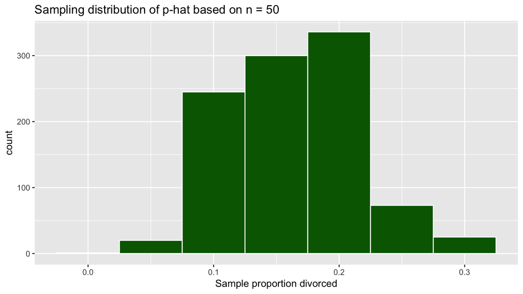

```r
ggplot(p_hat_n_50_1000_rep, aes(x = prop_divorced)) +
  geom_histogram(binwidth = 0.05, color = "white", fill = "darkgreen") +
  labs(x = "Sample proportion divorced", title = "Sampling distribution of p-hat based on n = 50")
```

## d) Standard error

Finally we can calculate the standard error, which is the standard deviation of the sampling distribution.

```r
p_hat_n_50_1000_rep %>%
  summarize(SE = sd(prop_divorced))
```

| SE |
| --- |
| 0.0509445 |

## e) Compare sampling distribution to true population parameter $p$

Let’s now calculate the true population proportion $p$ of `Divorced` respondents for the full `gss_14` data set like so. In other words, this would be like doing a *census* and asking everyone in the neighborhood if they are divorced or not.

```r
gss_14 %>%
  summarize(divorced = sum(marital == "Divorced")) %>%
  mutate(p_divorced = divorced / nrow(gss_14))
```

| divorced | p_divorced |
| --- | --- |
| 411 | 0.1619385 |

**Questions:**

1. Does it look like our sampling distribution as displayed in the histogram is centered at the true population proportion of `Divorced` respondents for all n=2538 people surveyed?
2. Is this what you expected?

**Answers:**

1. Yes, the histogram is centered on ~ 0.16.
2. I did expect this, since we collected a decently sized sample and ran 1000 reps, and since there is no reason to think that our R sampling is biased.

# Question 1

## a) Sampling a thousand replicates at n = 15

Now use the `rep_sample_n` function to collect 1000 virtual samples of size n = 15.

**Note: BE SURE TO NAME YOUR DATAFRAME WITH 1000 SAMPLES SOMETHING NEW, TO ENSURE YOU CAN DISTINGUISH IT FROM THE n = 50 SAMPLE ABOVE!**

```r
sample_n_15_1000_rep <- gss_14 %>%
  rep_sample_n(size = 15, reps = 1000)
```

## b) Calculate sample proportion $\widehat{p}$ for each replicate

Calculate the sample proportion $\widehat{p}$ of people who reported they were divorced for each of the 1000 replicates:

```r
p_hat_n_15_1000_rep <-sample_n_15_1000_rep %>%
  group_by(replicate) %>%
  summarize(divorced = sum(marital == "Divorced")) %>%
  mutate(prop_divorced = divorced / 15)
```

## c) Visualize the sampling distribution of $\widehat{p}$

Plot the sampling distribution of these 1000 simulated values of the sample proportion $\widehat{p}$ of divorced respondents with a histogram:

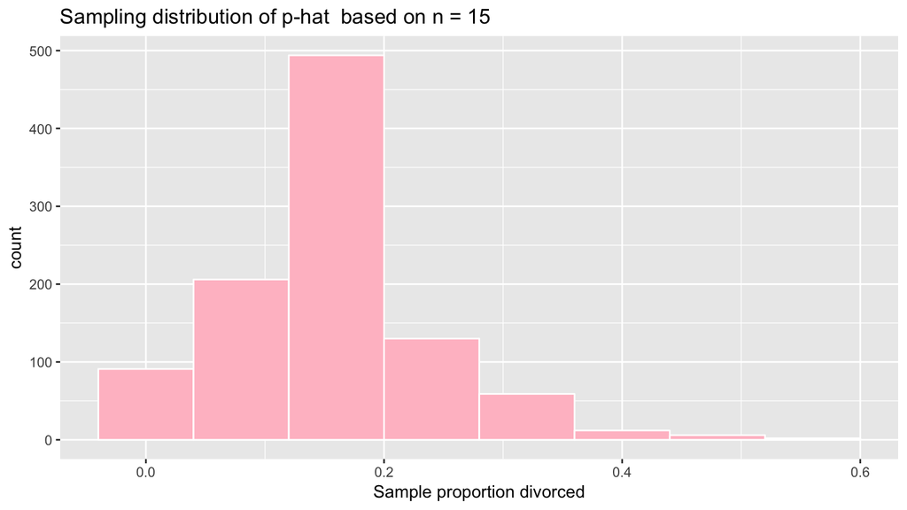

```r
ggplot(p_hat_n_15_1000_rep, aes(x = prop_divorced)) +
  geom_histogram(binwidth = 0.08, color = "white", fill = "pink") +
  labs(x = "Sample proportion divorced", title = "Sampling distribution of p-hat  based on n = 15")
```

**Question:**

1. How does this sampling distribution compare to the one you made earlier with a sample size *n* of 50?

**Answer**:

## d) Standard error

Calculate the standard error, which is the standard deviation of the sampling distribution.

```r
p_hat_n_15_1000_rep %>%
  summarize(SE = sd(prop_divorced))
```

| SE |
| --- |
| 0.0973597 |

**Question:**

1. How does this standard error compare to the one you made earlier with a sample size *n* of 50?

**Answer**:

1. The standard error is much larger at n = 15. It has nearly doubled.

# Question 2

## a) Sampling a thousand replicates at n = 400

Now use the `rep_sample_n` function to collect 1000 virtual samples of size n = 400.

**Note: BE SURE TO NAME YOUR DATAFRAME WITH 1000 SAMPLES SOMETHING NEW, TO ENSURE YOU CAN DISTINGUISH IT FROM THE n = 50 and n = 15 SAMPLES ABOVE!**

```r
sample_n_400_1000_rep <- gss_14 %>%
  rep_sample_n(size = 400, reps = 1000)
```

## b) Calculate sample proportion $\widehat{p}$ for each replicate

Calculate the proportion of people who reported they were divorced for each replicate.

```r
p_hat_n_400_1000_rep <-sample_n_400_1000_rep %>%
  group_by(replicate) %>%
  summarize(divorced = sum(marital == "Divorced")) %>%
  mutate(prop_divorced = divorced / 400)
```

## c) Visualize the sampling distribution of $\widehat{p}$

Plot the sampling distribution of these 1000 simulated values of the sample proportion of divorced respondents with a histogram.

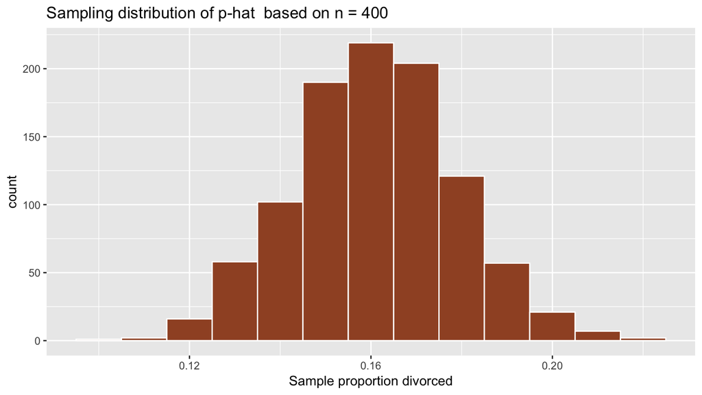

```r
ggplot(p_hat_n_400_1000_rep, aes(x = prop_divorced)) +
  geom_histogram(binwidth = 0.01, color = "white", fill = "sienna") +
  labs(x = "Sample proportion divorced", title = "Sampling distribution of p-hat  based on n = 400")
```

**Question:**

1. How does this sampling distribution compare to the one you made earlier with a sample size *n* of 50?

**Answer**:

1. It seems smaller, as it only spans from 0.12 to 0.21.

## d) Standard error

Calculate the standard error, which is the standard deviation of the sampling distribution.

```r
p_hat_n_400_1000_rep %>%
  summarize(SE = sd(prop_divorced))
```

| SE |
| --- |
| 0.0176593 |

**Question:**

1. How does this standard error compare to the one you made earlier with a sample size *n* of 50?

**Answer**:

# Question 3

**Questions:**

1. Which sampling distribution looked more normally distributed (bell shaped and symmetrical); the one built on n = 15, 50 or 400? Why?
2. Let’s pretend the GSS organizers can no longer afford to do a **full census** of this neighborhood in the future due to budget cuts. As their stats adviser, what sample size would you recommend they use?

**Answers**:

1. The sampling distribution for n = 400 looked more normally distributed. This is part of the central limit theorem…as your sample size increases, your sampling distribution becomes more normally distributed, and narrower (i.e. smaller spread)
2. I would suggest they use 400 in this neighborhood, given the lower SE. However, if they did not have the budget for it, even a sample size of 50 or maybe 100 may be adequate, so long as the sampling is not biased.

# Question 4

Now let’s sample values of a numerical variable `age` in order to estimate the **population mean** `age` $\mu$ of the “Independent” voters. The following will read in a data frame `age_ind_voters` that you should `View()` after loading:

```r
age_ind_voters <- read_csv("https://docs.google.com/spreadsheets/d/e/2PACX-1vQF_uMZ6_F8Qk-qnFbXc3qIa77lDu3ZkSFDJpBp19eYG-COsEPcNHVvCwQtG66P87VheH9nqn2p6igY/pub?gid=72203649&single=true&output=csv")
```

`age_ind_voters` contains the ages of all 4101 individuals in one neighborhood that identified their political party affiliation as “Independent”. This neighborhood will be our study population of interest and therefore the data in `age_ind_voters` represents a full **census** of the 4101 independent voters’ ages.

## a) Sampling a thousand replicates at n = 50

Use the `rep_sample_n()` function to sample 50 respondents from this population 1000 times. Save this as `sample_n_50_1000_rep`. Be sure to `View()` the results and scroll down to get a sense of these 1000 replicates look like. Note our sample size is still n = 50 i.e. how many humans are sampled in each replicate.

```r
sample_n_50_1000_rep <- age_ind_voters %>%
  rep_sample_n(size = 50, reps = 1000)
```

## b) Calculate sample mean $\bar{x}$ for each replicate

Use `group_by()` and `summarize()` on `sample_n_50_1000_rep` to calculate the sample mean $\bar{x}$ of age **for each of the 1000 replicates**; save these values in `x_bar_n_50_1000_rep`. We will use these values to construct the sampling distribution for the sample mean age $\bar{x}$ based on samples of size n = 50. Be sure to `View()` the results to check your work!

```r
x_bar_n_50_1000_rep <- sample_n_50_1000_rep %>%
  group_by(replicate) %>%
  summarize(mean_age = mean(age))
```

## c) Visualize the sampling distribution of $\bar{x}$

Plot the **sampling distribution** of the 1000 sample means $\bar{x}$ of age with a histogram. Give your histogram a meaningful x-axis label and title.

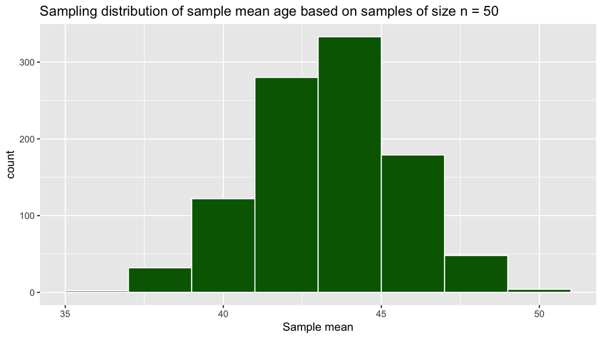

```r
ggplot(x_bar_n_50_1000_rep, aes(x = mean_age)) +
  geom_histogram(binwidth = 2, color = "white", fill = "darkgreen") +
  labs(
    x = "Sample mean",
    title = "Sampling distribution of sample mean age based on samples of size n = 50"
    )
```

## d) Center of sampling distribution

Numerically compute and output in your HTML document the values of:

1. The center of this sampling distribution
2. The true population mean age $\mu$.

```r
# Center of sampling distribution
x_bar_n_50_1000_rep %>%
  summarize(center = mean(mean_age))
```

| center |
| --- |
| 43.33872 |

```r
# True population mean
age_ind_voters %>%
  summarize(population_mean = mean(age))
```

| population_mean |
| --- |
| 43.27262 |

**Question**: Why are these two values close?

**Answer**: Because the sampling was done at random! While sometimes

1. the sample mean $\bar{x}$ will be greater than the true population mean $\mu$
2. the sample mean $\bar{x}$ will be less than the true population mean $\mu$

We expect on average different $\bar{x}$ values will be centered around the true population mean $\mu$. In other words, our estimates are accurate.

## e) Spread of sampling distribution: standard error

Calculate the standard error of the sample mean age $\bar{x}$, which is the standard deviation of the sampling distribution for $\bar{x}$.

```r
x_bar_n_50_1000_rep %>%
  summarize(SE = sd(mean_age))
```

| SE |
| --- |
| 2.265541 |

**Question**: If our sampling were based on samples of size n = 100 individuals instead, what would happen to the standard error?

**Answer**: It would get smaller. Bigger sample size n means more precise estimates $\bar{x}$ of $\mu$.